# Lab 5 - Checkpoint 4

Arnaldo Gualberto

05/07/2017

No checkpoint 4 do Lab 5, vamos analisar dados sobre *speed dating* (encontro rápido), que é um evento no qual participantes que nunca se viram antes conversam entre si, ao pares e de forma rápida, para conhecer novas pessoas. Ao final desses encontros, os participantes avaliam cada pessoa que eles conversaram e decidem se gostariam de conversar novamente com algum outro participante. Portanto, o objetivo desse checkpoint é analisar esses dados e responder as duas seguintes perguntas:

**1. Que fatores nos dados têm efeito significativo na chance do casal ter um match? E como é esse efeito (positivo/negativo)?**

**2. Que fatores nos dados têm mais efeito na chance de um casal ter match?**

# 0. Imports and Settings

```r
library(broom)
library(caret)
library(dplyr, warn.conflicts = FALSE)
library(GGally, warn.conflicts = FALSE)
library(ggplot2)
library(knitr)
library(pscl)
library(readr)
library(ROCR)

source('multiplot.R')

# Coloca todos os titulos dos gráficos centralizados
theme_update(plot.title = element_text(hjust=0.5))
```

# 1. Análise Descritiva

Antes de efetuar a regressão logística, vamos efetuar uma análise descritiva para conhecer melhor nossos dados. Primeiramente, vou carregar os nossos dados e selecionar as variáveis que eu acredito que serão relevantes para a nossa análise:

```r
dados <- read_csv('data/speed-dating2.csv') %>%
  dplyr::select(order, int_corr, age, age_o, attr, sinc, intel, fun, amb, shar, like, prob, dec) %>%
  mutate(dec = factor(dec)) %>%
  filter(complete.cases(.))
```

Ao todo, selecionei 13 variáveis, são elas:

- **order**: dos vários encontros realizados em uma noite por um participante, essa variável representa o n-ésimo
- **int_corr**: correlação entre os interesses de p1 e p2 (primeiro e segundo participante, respectivamente)
- **age**: idade de p1
- **age_o**: idade de p2
- **attr**: quão atraente p1 achou p2
- **sinc**: quão sincero p1 achou p2
- **intel**: quão inteligente p1 achou p2
- **fun**: quão divertido p1 achou p2
- **amb**: quão ambicioso p1 achou p2
- **shar**: quanto p1 achou que compartilha interesses e hobbies com p2
- **like**: no geral, quanto p1 gostou de p2?
- **prob**: que probabilidade p1 acha que p2 tem de querer se encontrar novamente com p1 (escala 1-10)
- **dec**: indica se houve o *match* entre os participantes do encontro

Agora, que conhecemos nossas variáveis, vamos analisar o sumário de cada uma delas:

```r
summary(dados) %>% kable()
```

|  | order | int_corr | age | age_o | attr | sinc | intel | fun | amb | shar | like | prob | dec |
| --- | --- | --- | --- | --- | --- | --- | --- | --- | --- | --- | --- | --- | --- |
|  | Min. : 1.000 | Min. :-0.7300 | Min. :18.00 | Min. :18.00 | Min. : 0.000 | Min. : 0.000 | Min. : 0.000 | Min. : 0.000 | Min. : 0.000 | Min. : 0.000 | Min. : 0.000 | Min. : 0.000 | no :2294 |
|  | 1st Qu.: 4.000 | 1st Qu.:-0.0300 | 1st Qu.:23.00 | 1st Qu.:23.00 | 1st Qu.: 5.000 | 1st Qu.: 6.000 | 1st Qu.: 6.000 | 1st Qu.: 5.000 | 1st Qu.: 6.000 | 1st Qu.: 4.000 | 1st Qu.: 5.000 | 1st Qu.: 4.000 | yes:1699 |
|  | Median : 8.000 | Median : 0.2100 | Median :25.00 | Median :25.00 | Median : 6.000 | Median : 7.000 | Median : 7.000 | Median : 6.000 | Median : 7.000 | Median : 5.000 | Median : 6.000 | Median : 5.000 | NA |
|  | Mean : 9.134 | Mean : 0.1912 | Mean :25.72 | Mean :25.73 | Mean : 6.048 | Mean : 7.025 | Mean : 7.251 | Mean : 6.279 | Mean : 6.684 | Mean : 5.309 | Mean : 6.047 | Mean : 5.031 | NA |
|  | 3rd Qu.:14.000 | 3rd Qu.: 0.4300 | 3rd Qu.:28.00 | 3rd Qu.:28.00 | 3rd Qu.: 7.000 | 3rd Qu.: 8.000 | 3rd Qu.: 8.000 | 3rd Qu.: 8.000 | 3rd Qu.: 8.000 | 3rd Qu.: 7.000 | 3rd Qu.: 7.000 | 3rd Qu.: 7.000 | NA |
|  | Max. :22.000 | Max. : 0.9000 | Max. :38.00 | Max. :39.00 | Max. :10.000 | Max. :10.000 | Max. :10.000 | Max. :10.000 | Max. :10.000 | Max. :10.000 | Max. :10.000 | Max. :10.000 | NA |

Pelo sumário, podemos ver que nenhuma delas aparenta apresentar nenhum outlier aparente. Além disso, podemos ver que tivemos 1699 matchings.

Vamos agora analisar a distribuição de cada uma das nossas variáveis independentes:

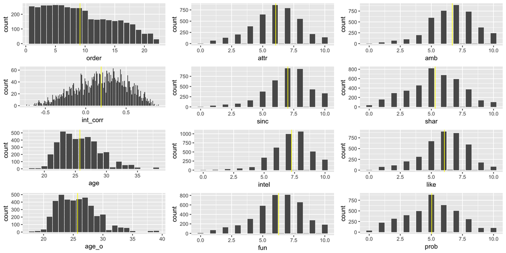

```r
barPlot <- function(data, column)
{
  plot <- data %>%
    ggplot(aes_string(x = column)) +
    geom_bar() +
    geom_vline(xintercept = mean(data[[column]]), color="yellow")
  return(plot)
}

p1 <- barPlot(dados, "order")
p2 <- barPlot(dados, "int_corr")
p3 <- barPlot(dados, "age")
p4 <- barPlot(dados, "age_o")
p5 <- barPlot(dados, "attr")
p6 <- barPlot(dados, "sinc")
p7 <- barPlot(dados, "intel")
p8 <- barPlot(dados, "fun")
p9 <- barPlot(dados, "amb")
p10 <- barPlot(dados, "shar")
p11 <- barPlot(dados, "like")
p12 <- barPlot(dados, "prob")

multiplot(p1, p2, p3, p4, p5, p6, p7, p8, p9, p10, p11, p12, cols = 3)
```

De acordo com os gráficos, acima, pode-se ver que a maioria das variáveis aparentam ter uma distribuição normal, com exceção da variável *order*. Nesse caso, a maioria dos participantes participam, em média, de aproximadamente 10 encontros em uma noite, enquanto alguns fazem mais de 20. Além disso, analisando a média das distribuições (linha amarela) podemos citar algumas informações interessantes sobre o perfil deles. Na média, temos participantes jovens com aproximadamente 25 anos, que acham p2 não tão sinceros (*sinc*) nem inteligentes (*intel*), interesses diferentes (*shar*), e indecisos (já que não tem certeza se p2 quer se encontrar novamente, $prob = 50\%$).

Vamos analisar esses mesmos gráficos quando comparamos os casos que deram *match* com os casos que não deram:

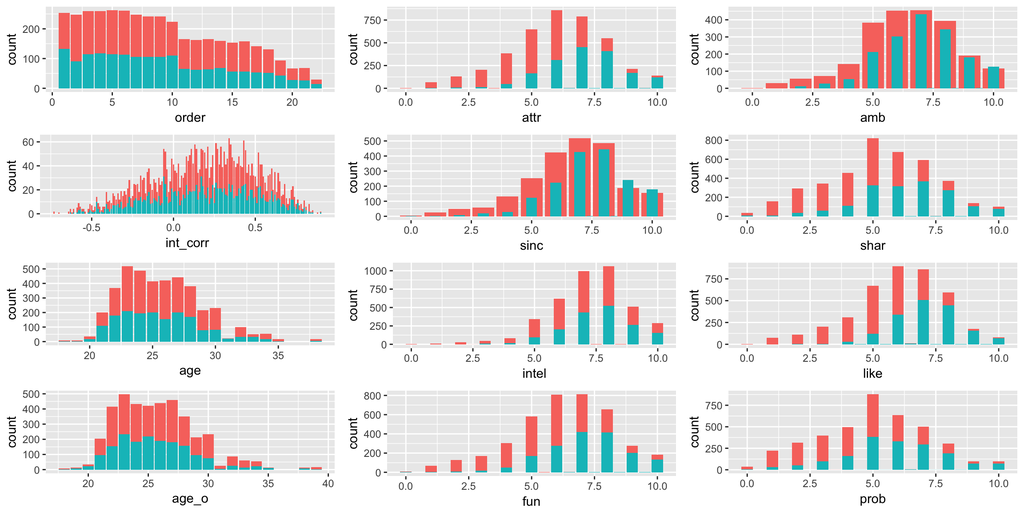

```r
barPlotMatch <- function(data, col1, col2)
{
  plot <- data %>%
    ggplot(aes_string(x = col1, fill=col2)) +
    geom_bar(position = "stack") +
    theme(legend.position = "none")
  return(plot)
}

p1 <-barPlotMatch(dados, "order", "dec")
p2 <-barPlotMatch(dados, "int_corr", "dec")
p3 <-barPlotMatch(dados, "age", "dec")
p4 <-barPlotMatch(dados, "age_o", "dec")
p5 <-barPlotMatch(dados, "attr", "dec")
p6 <-barPlotMatch(dados, "sinc", "dec")
p7 <-barPlotMatch(dados, "intel", "dec")
p8 <-barPlotMatch(dados, "fun", "dec")
p9 <-barPlotMatch(dados, "amb", "dec")
p10 <-barPlotMatch(dados, "shar", "dec")
p11 <-barPlotMatch(dados, "like", "dec")
p12 <-barPlotMatch(dados, "prob", "dec")

multiplot(p1, p2, p3, p4, p5, p6, p7, p8, p9, p10, p11, p12, cols = 3)
```

**Nota**: repare que os gráficos de *sinc* e *amb* não puderam ser empilhados.

Vamos agora analisar a distribuição de cada variável em relação a *dec* usando boxplots:

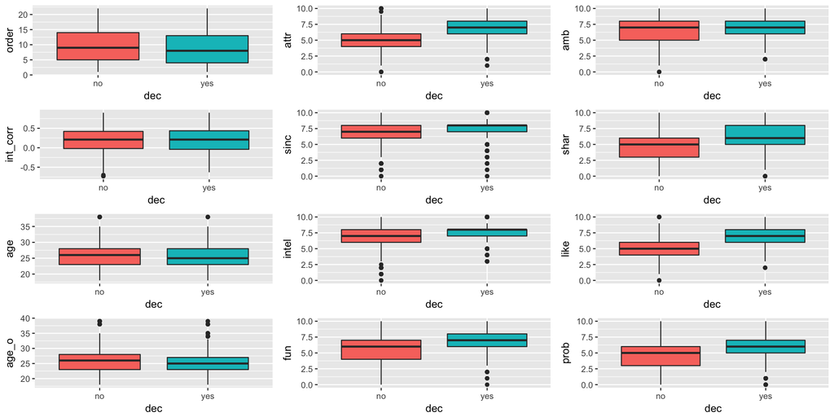

```r
boxPlot <- function(data, col1, col2)
{
  plot <- data %>%
    ggplot(aes_string(x = col2, y = col1, fill = col2)) +
    geom_boxplot() +
    theme(legend.position = "none")
  return(plot)
}

p1 <- boxPlot(dados, "order", "dec")
p2 <- boxPlot(dados, "int_corr", "dec")
p3 <- boxPlot(dados, "age", "dec")
p4 <- boxPlot(dados, "age_o", "dec")
p5 <- boxPlot(dados, "attr", "dec")
p6 <- boxPlot(dados, "sinc", "dec")
p7 <- boxPlot(dados, "intel", "dec")
p8 <- boxPlot(dados, "fun", "dec")
p9 <- boxPlot(dados, "amb", "dec")
p10 <- boxPlot(dados, "shar", "dec")
p11 <- boxPlot(dados, "like", "dec")
p12 <- boxPlot(dados, "prob", "dec")

multiplot(p1, p2, p3, p4, p5, p6, p7, p8, p9, p10, p11, p12, cols = 3)
```

Pelos boxplots acima, podemos observar que a mediana dos matchs (*dec* = "yes") é maior para praticamente todas as variáveis, com exceção de *order*, *int_corr*, *age* e *age_o*. As distância inter-quartis também são parecidas em geral. O gráfico de *sinc* nos mostra que houveram algumas pessoas que deram match em p2, mesmo considerando p2 uma pessoa não sincera.

Vamos analisar agora o gráfico que talvez será o mais importante para prever o resultado da regressão logística, plotando cada variável em relação a *dec*:

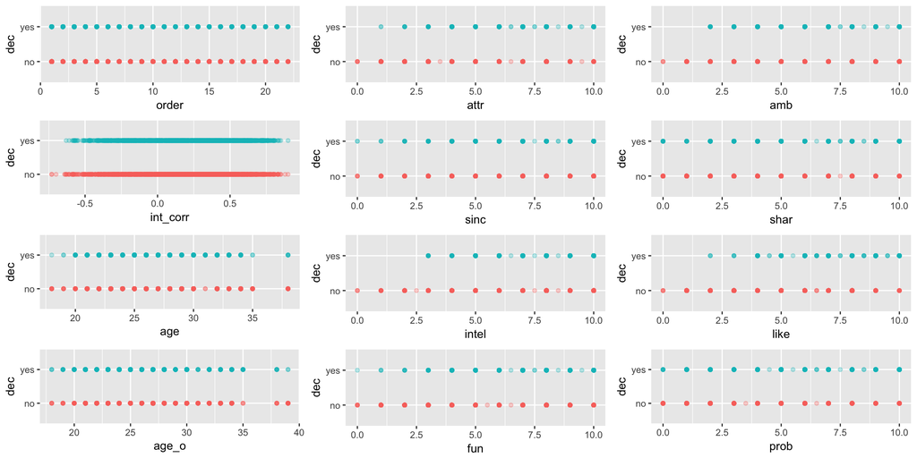

```r
scatterPlot <- function(data, col1, col2)
{
  plot <- data %>%
    ggplot(aes_string(x = col1, y = col2, colour = col2)) +
    geom_point(alpha=0.3) +
    theme(legend.position = "none")
  return(plot)
}

p1 <- scatterPlot(dados, "order", "dec")
p2 <- scatterPlot(dados, "int_corr", "dec")
p3 <- scatterPlot(dados, "age", "dec")
p4 <- scatterPlot(dados, "age_o", "dec")
p5 <- scatterPlot(dados, "attr", "dec")
p6 <- scatterPlot(dados, "sinc", "dec")
p7 <- scatterPlot(dados, "intel", "dec")
p8 <- scatterPlot(dados, "fun", "dec")
p9 <- scatterPlot(dados, "amb", "dec")
p10 <- scatterPlot(dados, "shar", "dec")
p11 <- scatterPlot(dados, "like", "dec")
p12 <- scatterPlot(dados, "prob", "dec")

multiplot(p1, p2, p3, p4, p5, p6, p7, p8, p9, p10, p11, p12, cols = 3)
```

De acordos com os gráficos acima, eu arriscaria dizer as variáveis *intel*, *amb* e *like* seriam as variáveis mais importantes estatisticamente para o resultado da regressão logística, uma vez que a ocorrência de match (*dec* = "yes") em geral se concentra mais a direita do que o caso contrário. Lembrando que isso é apenas intuição. Além disso, eu arriscaria dizer que *int_corr*, *order*, *age*, *age_o* não seriam estatisticamente significantes, uma vez que visualmente são extremamente difíceis de separar utilizando algum critério. Em relação as outras variáveis, eu não saberia dizer a significância estatística delas.

Vamos, então, ver se algum palpite meu está correto.

# 2. Regressão Logística

Como dito anteriormente, o objetivo da nossa regressão logística é ver quais fatores são mais significativos e a importância desses fatores. Também devemos analisar como se dá esse efeito (positivo/negativo). Para isso, vamos começar ajustando nosso modelo:

```r
mod <- glm(dec ~ ., data = dados, family = "binomial")

summary(mod)
```

```
##
## Call:
## glm(formula = dec ~ ., family = "binomial", data = dados)
##
## Deviance Residuals:
##     Min       1Q   Median       3Q      Max
## -2.8704  -0.7463  -0.2098   0.7764   3.5729
##
## Coefficients:
##               Estimate Std. Error z value Pr(>|z|)
## (Intercept) -5.6358524  0.5227125 -10.782  < 2e-16 ***
## order       -0.0112510  0.0072758  -1.546 0.122018
## int_corr    -0.1002226  0.1323884  -0.757 0.449029
## age         -0.0006313  0.0127301  -0.050 0.960445
## age_o       -0.0073243  0.0124544  -0.588 0.556472
## attr         0.4353793  0.0313792  13.875  < 2e-16 ***
## sinc        -0.2308857  0.0347047  -6.653 2.87e-11 ***
## intel       -0.0464791  0.0423157  -1.098 0.272034
## fun          0.1249637  0.0337252   3.705 0.000211 ***
## amb         -0.2152921  0.0327979  -6.564 5.23e-11 ***
## shar         0.1561902  0.0272317   5.736 9.72e-09 ***
## like         0.6141881  0.0440983  13.928  < 2e-16 ***
## prob         0.1626969  0.0233889   6.956 3.50e-12 ***
## ---
## Signif. codes:  0 '***' 0.001 '**' 0.01 '*' 0.05 '.' 0.1 ' ' 1
##
## (Dispersion parameter for binomial family taken to be 1)
##
##     Null deviance: 5446.5  on 3992  degrees of freedom
## Residual deviance: 3691.3  on 3980  degrees of freedom
## AIC: 3717.3
##
## Number of Fisher Scoring iterations: 5
```

Pelo sumário acima, podemos ver que as variáveis estatisticamente significantes são: *attr*, *sinc*, *fun*, *amb*, *shar*, *like* e *prob* - uma vez que os intervalos de confiança não interceptam zero (nota: os coeficientes acima não estão exponenciados). **Em relação a essas variáveis, apenas *sinc* e *amb* apresentam efeito negativo, ou seja, quando a percepção de sinceridade ou ambição que p1 tem sobre p2 aumenta, a chance de dar matching diminui. Todas as outras variáveis singificantes apresentam efeito positivo. Entre essas variáveis, a que apresenta o maior coeficiente é **like** (0.61), seguida por *attr* (0.43)**. Isso significa que, aumentando **like** em uma unidade, por exemplo, e mantendo as demais constantes, o log de *odds ratio* aumenta em 0.61.

Lembrando que *odds ratio (OR)* é a chance de um evento ocorrer sobre a chance do evento não ocorrer $\frac{p}{1-p}$, também chamada de **razão de chances** ou **razão de possibilidades**. Uma OR = 1 significa que a condição do evento ocorrer é igualmente provável a chance de não ocorrer. Logo, quando OR > 1, a chance do evento ocorrer é maior que não ocorrer. Por outro lado, quando OR < 1, a probabilidade do evento ocorrer é menor.

Como o log de odds é difícil de interpretar, em geral, exponenciamos esses coeficientes:

```r
tidy(mod, conf.int = TRUE) %>% kable() # == summary
```

| term | estimate | std.error | statistic | p.value | conf.low | conf.high |
| --- | --- | --- | --- | --- | --- | --- |
| (Intercept) | -5.6358524 | 0.5227125 | -10.7819355 | 0.0000000 | -6.6672493 | -4.6176183 |
| order | -0.0112510 | 0.0072758 | -1.5463594 | 0.1220178 | -0.0255298 | 0.0029984 |
| int_corr | -0.1002226 | 0.1323884 | -0.7570348 | 0.4490290 | -0.3598227 | 0.1592841 |
| age | -0.0006313 | 0.0127301 | -0.0495948 | 0.9604453 | -0.0256031 | 0.0243165 |
| age_o | -0.0073243 | 0.0124544 | -0.5880905 | 0.5564715 | -0.0317780 | 0.0170599 |
| attr | 0.4353793 | 0.0313792 | 13.8747933 | 0.0000000 | 0.3743318 | 0.4973812 |
| sinc | -0.2308857 | 0.0347047 | -6.6528712 | 0.0000000 | -0.2992512 | -0.1631598 |
| intel | -0.0464791 | 0.0423157 | -1.0983896 | 0.2720344 | -0.1296097 | 0.0363172 |
| fun | 0.1249637 | 0.0337252 | 3.7053461 | 0.0002111 | 0.0590215 | 0.1912668 |
| amb | -0.2152921 | 0.0327979 | -6.5642128 | 0.0000000 | -0.2799037 | -0.1512973 |
| shar | 0.1561902 | 0.0272317 | 5.7355971 | 0.0000000 | 0.1029640 | 0.2097501 |
| like | 0.6141881 | 0.0440983 | 13.9277096 | 0.0000000 | 0.5286384 | 0.7015660 |
| prob | 0.1626969 | 0.0233889 | 6.9561556 | 0.0000000 | 0.1169749 | 0.2086876 |

```r
tidy(mod, conf.int = TRUE, exponentiate = TRUE) %>% kable()
```

| term | estimate | std.error | statistic | p.value | conf.low | conf.high |
| --- | --- | --- | --- | --- | --- | --- |
| (Intercept) | 0.0035676 | 0.5227125 | -10.7819355 | 0.0000000 | 0.0012719 | 0.0098763 |
| order | 0.9888121 | 0.0072758 | -1.5463594 | 0.1220178 | 0.9747933 | 1.0030029 |
| int_corr | 0.9046360 | 0.1323884 | -0.7570348 | 0.4490290 | 0.6978000 | 1.1726711 |
| age | 0.9993689 | 0.0127301 | -0.0495948 | 0.9604453 | 0.9747218 | 1.0246145 |
| age_o | 0.9927025 | 0.0124544 | -0.5880905 | 0.5564715 | 0.9687216 | 1.0172063 |
| attr | 1.5455492 | 0.0313792 | 13.8747933 | 0.0000000 | 1.4540194 | 1.6444092 |
| sinc | 0.7938302 | 0.0347047 | -6.6528712 | 0.0000000 | 0.7413732 | 0.8494555 |
| intel | 0.9545845 | 0.0423157 | -1.0983896 | 0.2720344 | 0.8784382 | 1.0369847 |
| fun | 1.1331073 | 0.0337252 | 3.7053461 | 0.0002111 | 1.0607980 | 1.2107824 |
| amb | 0.8063059 | 0.0327979 | -6.5642128 | 0.0000000 | 0.7558565 | 0.8595921 |
| shar | 1.1690485 | 0.0272317 | 5.7355971 | 0.0000000 | 1.1084515 | 1.2333699 |
| like | 1.8481555 | 0.0440983 | 13.9277096 | 0.0000000 | 1.6966205 | 2.0169088 |
| prob | 1.1766800 | 0.0233889 | 6.9561556 | 0.0000000 | 1.1240913 | 1.2320600 |

Agora, podemos ver que **aumentando **like** por uma unidade, a chance de ocorrer um matching aumenta 84.8%. Por outro lado, a chance de ocorrer matching entre participantes que consideraram a outra pessoa sincera é 20.7% menor a cada ponto de sinceridade a mais (mantendo fixa as demais variáveis)**.

**Importante**: a exponenciação dos expoentes altera a avaliação do intervalo de confiança. Na regressão linear, para uma variável ser considerada estatisticamente significante, o seu intervalo de confiança não pode interceptar zero (com exceção do intercept, que tanto faz). Na regressão logística, por sua vez, quando exponenciamos os coeficientes, o intervalo de confiança não pode interceptar 1. Pois, quando o CI é maior que 1, significa que o odds ratio aumenta à medida que se aumenta a variável independente. De modo análogo, quando o CI é menor que 1, o odds ratio diminui com o aumento da variável independente. Portanto, quando o CI intercepta o valor 1, não podemos afirmar o efeito da variável independente sobre o odds ratio.

**Observação**: Também é importante notar que quando o coeficiente (não exponenciado) é negativo, o coeficiente exponenciado é sempre menor que 1. Por outro lado, quando o coeficiente é positivo, o coeficiente exponenciado é sempre maior que 1. No entanto, o sinal do coeficiente (não exponenciado) ou seu valor (exponenciado) diz fatos interessantes sobre as variáveis. Quando o coeficiente (não exponenciado) é negativo (ou menor que 1 ao exponenciar), significa que a variável em questão contribui negativamente em relação a variável dependente (resposta). Por exemplo, como visto anteriormente, levando em consideração a variável *sinc* (estatisticamente significante), quanto mais sincero a pessoa é, menor a chance de ocorrer o matching - aproximadamente 20.7% menor a cada ponto a mais de sinceridade (quando todas as outras variáveis se mantém constante).

Vamos, então, analisar os efeitos de *like* e *sinc* quanto todas as variáveis se mantém fixas e iguais as suas respectivas médias:

```r
teste <- with(dados, data.frame(order=mean(order), int_corr=mean(int_corr), age=mean(age), age_o=mean(age_o), attr=mean(attr), sinc=mean(sinc), intel=mean(intel), fun=mean(fun), amb=mean(amb), shar=mean(shar), prob=mean(prob), like = c(5:10)))
teste$pred <- predict(mod, teste, type = "response")
teste %>% kable()
```

| order | int_corr | age | age_o | attr | sinc | intel | fun | amb | shar | prob | like | pred |
| --- | --- | --- | --- | --- | --- | --- | --- | --- | --- | --- | --- | --- |
| 9.133734 | 0.1911545 | 25.72352 | 25.73278 | 6.048209 | 7.025419 | 7.250939 | 6.279113 | 6.683696 | 5.309166 | 5.031305 | 5 | 0.2272619 |
| 9.133734 | 0.1911545 | 25.72352 | 25.73278 | 6.048209 | 7.025419 | 7.250939 | 6.279113 | 6.683696 | 5.309166 | 5.031305 | 6 | 0.3521393 |
| 9.133734 | 0.1911545 | 25.72352 | 25.73278 | 6.048209 | 7.025419 | 7.250939 | 6.279113 | 6.683696 | 5.309166 | 5.031305 | 7 | 0.5011348 |
| 9.133734 | 0.1911545 | 25.72352 | 25.73278 | 6.048209 | 7.025419 | 7.250939 | 6.279113 | 6.683696 | 5.309166 | 5.031305 | 8 | 0.6499291 |
| 9.133734 | 0.1911545 | 25.72352 | 25.73278 | 6.048209 | 7.025419 | 7.250939 | 6.279113 | 6.683696 | 5.309166 | 5.031305 | 9 | 0.7743285 |
| 9.133734 | 0.1911545 | 25.72352 | 25.73278 | 6.048209 | 7.025419 | 7.250939 | 6.279113 | 6.683696 | 5.309166 | 5.031305 | 10 | 0.8637867 |

Pode-se observar que **quando $like=5$, a chance de ocorrer um matching é aproximadamente 22,7%. Já quando $like=10$, essa probabilidade sobre para 86,3%.**

```r
teste <- with(dados, data.frame(order=mean(order), int_corr=mean(int_corr), age=mean(age), age_o=mean(age_o), attr=mean(attr), intel=mean(intel), fun=mean(fun), amb=mean(amb), shar=mean(shar), prob=mean(prob), like=mean(like), sinc=c(5:10)))
teste$pred <- predict(mod, teste, type = "response")
teste %>% kable()
```

| order | int_corr | age | age_o | attr | intel | fun | amb | shar | prob | like | sinc | pred |
| --- | --- | --- | --- | --- | --- | --- | --- | --- | --- | --- | --- | --- |
| 9.133734 | 0.1911545 | 25.72352 | 25.73278 | 6.048209 | 7.250939 | 6.279113 | 6.683696 | 5.309166 | 5.031305 | 6.046582 | 5 | 0.4716807 |
| 9.133734 | 0.1911545 | 25.72352 | 25.73278 | 6.048209 | 7.250939 | 6.279113 | 6.683696 | 5.309166 | 5.031305 | 6.046582 | 6 | 0.4147692 |
| 9.133734 | 0.1911545 | 25.72352 | 25.73278 | 6.048209 | 7.250939 | 6.279113 | 6.683696 | 5.309166 | 5.031305 | 6.046582 | 7 | 0.3600447 |
| 9.133734 | 0.1911545 | 25.72352 | 25.73278 | 6.048209 | 7.250939 | 6.279113 | 6.683696 | 5.309166 | 5.031305 | 6.046582 | 8 | 0.3087316 |
| 9.133734 | 0.1911545 | 25.72352 | 25.73278 | 6.048209 | 7.250939 | 6.279113 | 6.683696 | 5.309166 | 5.031305 | 6.046582 | 9 | 0.2617406 |
| 9.133734 | 0.1911545 | 25.72352 | 25.73278 | 6.048209 | 7.250939 | 6.279113 | 6.683696 | 5.309166 | 5.031305 | 6.046582 | 10 | 0.2196295 |

Por outro lado, quando p1 acha p2 extremamente sincero ($sinc =10$), **a probabilidade de matching é apenas 21.9%. Porém, quando essa percepção de sinceridade diminui ($sinc=5$), a chance de matching sobre 47.1%**. *Será que não é bom ser sincero demais ou as pessoas apenas gostam de fingir que estão sendo enganadas?*

Por fim, vamos analisar algumas métricas no nosso regressor logístico:

```r
teste <- dados
teste$pred <- predict(mod, teste, type = "response") # teste$pred contém a probabilidade P(y="yes"|x)
teste$result <- ifelse(teste$pred > 0.5, "yes", "no")
confusionMatrix(dados$dec, teste$result, positive = "yes")
```

```
## Confusion Matrix and Statistics
##
##           Reference
## Prediction   no  yes
##        no  1861  433
##        yes  484 1215
##
##                Accuracy : 0.7703
##                  95% CI : (0.757, 0.7833)
##     No Information Rate : 0.5873
##     P-Value [Acc > NIR] : < 2e-16
##
##                   Kappa : 0.5284
##  Mcnemar's Test P-Value : 0.09871
##
##             Sensitivity : 0.7373
##             Specificity : 0.7936
##          Pos Pred Value : 0.7151
##          Neg Pred Value : 0.8112
##              Prevalence : 0.4127
##          Detection Rate : 0.3043
##    Detection Prevalence : 0.4255
##       Balanced Accuracy : 0.7654
##
##        'Positive' Class : yes
##
```

O resultado acima nos mostra que **apesar da taxa de acerto ser baixa (77.03%), a nossa regressão logística é boa em prever os casos de não matching (81.12%)**. Além disso, o intervalo de confiança para acurácia do nosso regressor é [75.7%, 78.3%].

```r
pR2(mod)
```

```
##           llh       llhNull            G2      McFadden          r2ML
## -1845.6447462 -2723.2404589  1755.1914254     0.3222616     0.3556847
##          r2CU
##     0.4778360
```

Finalmente, a curva ROC do nosso regressor pode ser vista abaixo:

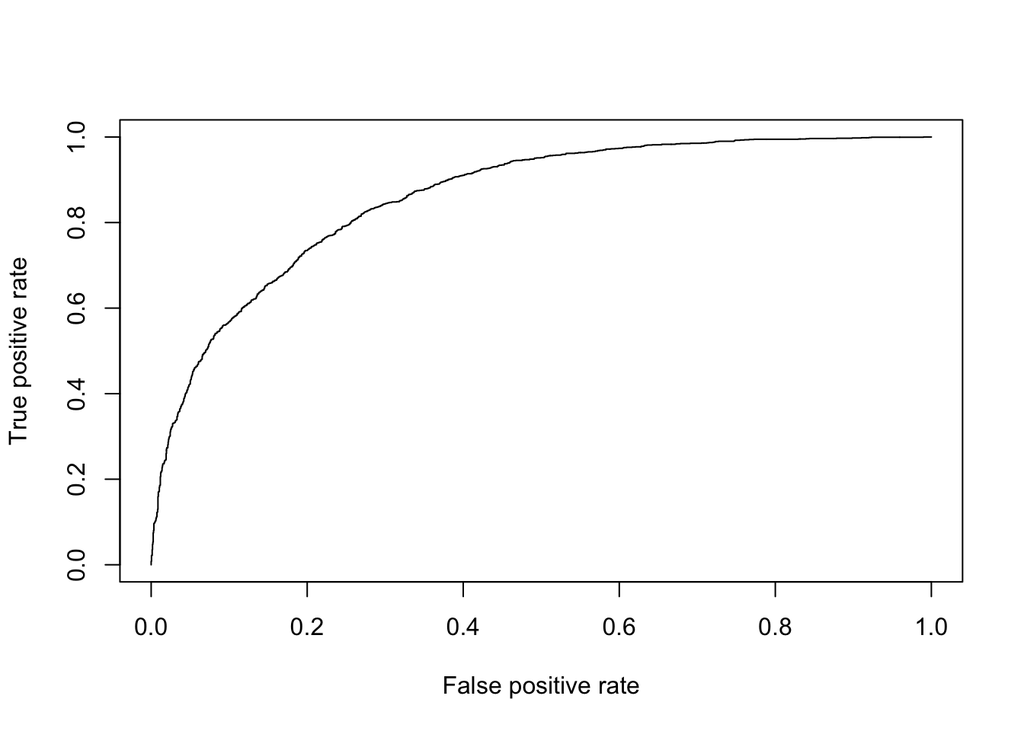

```r
pr <- prediction(teste$pred, teste$dec)
prf <- performance(pr, measure = "tpr", x.measure = "fpr")
plot(prf)
```

```r
auc <- performance(pr, measure = "auc")
auc <- auc@y.values[[1]]
auc
```

```
## [1] 0.8580754
```

A área sob a curva (*Área Under Curve, AUC*) do nosso regressor é 85.8%.

# 3. Conclusões